# Tutorial-on-Notebook-SparkR

In this notebook, we will show how to how to use R & SparkR with some examples in Jupyter Notebook.

1. Working with System Commands
2. Working with SparkR  
   2.1 Retrieving Files from FHIR HDFS  
   2.2 Retrieving Files from Data Mart  
   2.3 Converting from SparkR to R Data Frame  
   2.4 Converting from R to SparkR Data Frame

## 1. System Commands

Output display options. The default display is cols=20 and rows=60. If you would like to more columns and rows in R on Jupyter and use a scroll bar to controll it, the following setting could be applied.

```r
options(repr.matrix.max.cols=50, repr.matrix.max.rows=10000)
```

To get the cuurent working directory.

```r
getwd()
```

'/home/spark/Quan/Demos'

List all files in the current directory.

```r
list.files()
```

1. 'demo-CKD-PySpark.ipynb'

2. 'demo-CKD-Python.ipynb'

3. 'demo-FHIR.ipynb'

4. 'demo-PIMA-PySpark.ipynb'

5. 'demo-PIMA-Python.ipynb'

6. 'demo-WBC-PySpark.ipynb'

7. 'demo-WBC-Python.ipynb'

8. 'derby.log'

9. 'Tutorial on Notebook and PySpark.ipynb'

10. 'Tutorial on Notebook and SparkR.ipynb'

Copy one file from one path to the other path.

```r
# file.copy ('/home/spark/Azka/demo-ckd-pyspark.ipynb','/home/spark/Michael/Demos/demo-ckd-pyspark.ipynb')
```

Print out the current R version related information.

```r
R.Version()
```

**$platform**

'x86_64-redhat-linux-gnu'

**$arch**

'x86_64'

**$os**

'linux-gnu'

**$system**

'x86_64, linux-gnu'

**$status**

''

**$major**

'3'

**$minor**

'3.3'

**$year**

'2017'

**$month**

'03'

**$day**

'06'

**$`svn rev`**

'72310'

**$language**

'R'

**$version.string**

'R version 3.3.3 (2017-03-06)'

**$nickname**

'Another Canoe'

List all available packages.

```r
rownames(installed.packages())
```

**ret0**

'SparkR'

**2**

'assertthat'

**3**

'base'

**4**

'base64enc'

**5**

'BH'

**6**

'boot'

**7**

'class'

**8**

'cluster'

**9**

'codetools'

**10**

'coin'

**11**

'colorspace'

**12**

'compiler'

**13**

'crayon'

**14**

'datasets'

**15**

'date'

**16**

'DBI'

**17**

'debugme'

**18**

'dichromat'

**19**

'digest'

**20**

'dplyr'

**21**

'e1071'

**22**

'evaluate'

**23**

'forecast'

**24**

'foreign'

**25**

'fracdiff'

**26**

'gdata'

**27**

'ggplot2'

**28**

'graphics'

**29**

'grDevices'

**30**

'grid'

**31**

'gtable'

**32**

'gtools'

**33**

'IRdisplay'

**34**

'IRkernel'

**35**

'jsonlite'

**36**

'KernSmooth'

**37**

'labeling'

**38**

'lattice'

**39**

'lazyeval'

**40**

'magrittr'

**41**

'MASS'

**42**

'Matrix'

**43**

'methods'

**44**

'mgcv'

**45**

'modeltools'

**46**

'multcomp'

**47**

'munsell'

**48**

'mvtnorm'

**49**

'NbClust'

**50**

'nlme'

**51**

'nnet'

**52**

'parallel'

**53**

'party'

**54**

'pbdZMQ'

**55**

'plyr'

**56**

'processx'

**57**

'quadprog'

**58**

'R6'

**59**

'RColorBrewer'

**60**

'Rcpp'

**61**

'RcppArmadillo'

**62**

'repr'

**63**

'reshape2'

**64**

'reticulate'

**65**

'rpart'

**66**

'RUnit'

**67**

'rzmq'

**68**

'sandwich'

**69**

'scales'

**70**

'spatial'

**71**

'splines'

**72**

'stats'

**73**

'stats4'

**74**

'stringi'

**75**

'stringr'

**76**

'strucchange'

**77**

'survival'

**78**

'tcltk'

**79**

'tensorflow'

**80**

'TH.data'

**81**

'tibble'

**82**

'timeDate'

**83**

'tools'

**84**

'tseries'

**85**

'utils'

**86**

'uuid'

**87**

'yaml'

**88**

'zoo'

## 2. Working with SparkR

```r
library(SparkR)
```

#### Initializing Spark context

```r
sc <- sparkR.init(master='yarn-client', sparkEnvir = list(spark.yarn.dist.archives='/usr/iop/current/spark-client/R/lib/sparkr.zip#sparkr'))

sqlContext <- sparkRSQL.init(sc)
```

```
Launching java with spark-submit command /usr/iop/current/spark-client/bin/spark-submit   sparkr-shell /tmp/RtmpeGr4bs/backend_port57451586dc49
```

#### Search for files under all apps in FHIR HDFS

```r
system("hadoop fs -ls /data/lsf/lsf_appname=*", intern = TRUE)
```

1. 'Found 1 items'

2. 'drwxr-xr-x - htmanager hdfs 0 2017-10-08 22:45 /data/lsf/lsf_appname=AbCd-%123aB/lsf_resourcetype=QuestionnaireResponse'

3. 'Found 1 items'

4. 'drwxr-xr-x - htmanager hdfs 0 2017-10-12 17:12 /data/lsf/lsf_appname=a1%%_23#4/lsf_resourcetype=Device'

5. 'Found 13 items'

6. 'drwxr-xr-x - anonexport hdfs 0 2017-10-25 13:32 /data/lsf/lsf_appname=ci34/lsf_resourcetype=CarePlan'

7. 'drwxr-xr-x - anonexport hdfs 0 2017-10-25 14:16 /data/lsf/lsf_appname=ci34/lsf_resourcetype=Device'

8. 'drwxr-xr-x - anonexport hdfs 0 2017-10-25 14:19 /data/lsf/lsf_appname=ci34/lsf_resourcetype=DeviceComponent'

9. 'drwxr-xr-x - htmanager hdfs 0 2017-10-25 13:45 /data/lsf/lsf_appname=ci34/lsf_resourcetype=DeviceMetric'

10. 'drwxr-xr-x - htmanager hdfs 0 2017-10-25 13:45 /data/lsf/lsf_appname=ci34/lsf_resourcetype=Group'

11. 'drwxr-xr-x - htmanager hdfs 0 2017-10-25 13:44 /data/lsf/lsf_appname=ci34/lsf_resourcetype=Medication'

12. 'drwxr-xr-x - htmanager hdfs 0 2017-10-25 13:40 /data/lsf/lsf_appname=ci34/lsf_resourcetype=MedicationAdministration'

13. 'drwxr-xr-x - htmanager hdfs 0 2017-10-25 13:40 /data/lsf/lsf_appname=ci34/lsf_resourcetype=MedicationOrder'

14. 'drwxr-xr-x - anonexport hdfs 0 2017-10-25 13:37 /data/lsf/lsf_appname=ci34/lsf_resourcetype=Observation'

15. 'drwxr-xr-x - anonexport hdfs 0 2017-10-25 13:37 /data/lsf/lsf_appname=ci34/lsf_resourcetype=Organization'

16. 'drwxr-xr-x - anonexport hdfs 0 2017-10-25 13:37 /data/lsf/lsf_appname=ci34/lsf_resourcetype=Practitioner'

17. 'drwxr-xr-x - anonexport hdfs 0 2017-10-25 13:36 /data/lsf/lsf_appname=ci34/lsf_resourcetype=Questionnaire'

18. 'drwxr-xr-x - anonexport hdfs 0 2017-10-25 13:35 /data/lsf/lsf_appname=ci34/lsf_resourcetype=QuestionnaireResponse'

19. 'Found 12 items'

20. 'drwxr-xr-x - anonexport hdfs 0 2017-09-27 19:22 /data/lsf/lsf_appname=null/lsf_resourcetype=CarePlan'

21. 'drwxr-xr-x - anonexport hdfs 0 2017-09-27 18:04 /data/lsf/lsf_appname=null/lsf_resourcetype=Device'

22. 'drwxr-xr-x - anonexport hdfs 0 2017-09-27 18:04 /data/lsf/lsf_appname=null/lsf_resourcetype=DeviceComponent'

23. 'drwxr-xr-x - anonexport hdfs 0 2017-09-27 19:22 /data/lsf/lsf_appname=null/lsf_resourcetype=DeviceMetric'

24. 'drwxr-xr-x - anonexport hdfs 0 2017-10-11 23:55 /data/lsf/lsf_appname=null/lsf_resourcetype=Group'

25. 'drwxr-xr-x - anonexport hdfs 0 2017-10-11 23:55 /data/lsf/lsf_appname=null/lsf_resourcetype=Medication'

26. 'drwxr-xr-x - anonexport hdfs 0 2017-09-27 18:04 /data/lsf/lsf_appname=null/lsf_resourcetype=MedicationAdministration'

27. 'drwxr-xr-x - anonexport hdfs 0 2017-09-27 18:05 /data/lsf/lsf_appname=null/lsf_resourcetype=MedicationOrder'

28. 'drwxr-xr-x - anonexport hdfs 0 2017-09-27 18:05 /data/lsf/lsf_appname=null/lsf_resourcetype=Observation'

29. 'drwxr-xr-x - anonexport hdfs 0 2017-10-11 23:55 /data/lsf/lsf_appname=null/lsf_resourcetype=Organization'

30. 'drwxr-xr-x - anonexport hdfs 0 2017-10-11 23:55 /data/lsf/lsf_appname=null/lsf_resourcetype=Questionnaire'

31. 'drwxr-xr-x - anonexport hdfs 0 2017-09-27 18:05 /data/lsf/lsf_appname=null/lsf_resourcetype=QuestionnaireResponse'

32. 'Found 2 items'

33. 'drwxr-xr-x - htmanager hdfs 0 2017-10-08 22:48 /data/lsf/lsf_appname=xyz-Ab/lsf_resourcetype=Device'

34. 'drwxr-xr-x - htmanager hdfs 0 2017-10-08 22:47 /data/lsf/lsf_appname=xyz-Ab/lsf_resourcetype=QuestionnaireResponse'

### 2.1 Retrieving files from FHIR HDFS

For more information about interaction with data reservoir FHIR HDFS, please refer to Azka (SparkR) and Ariella(PySpark)'s demos.

```r
path <- "/data/lsf/lsf_appname=null/lsf_resourcetype=CarePlan"
df <- SparkR:::read.df(sqlContext=sqlContext, source="parquet",path=path)
str(df)
```

```
'DataFrame': 46 variables:
 $ activity           : arr NA NA NA NA NA NA
 $ addresses          : arr NA NA NA NA NA NA
 $ appName            : chr "NA" "NA" "NA" "NA" "NA" "NA"
 $ author             : arr NA NA NA NA NA NA
 $ basedOn            : arr NA NA NA NA NA NA
 $ careTeam           : arr NA NA NA NA NA NA
 $ category           : arr NA NA NA NA NA NA
 $ contained          : arr list(list(code = list(coding = NA, text = "Obesity"), description = NA, extension = NA, id =
 $ context            : str NA NA NA NA NA NA
 $ definition         : arr NA NA NA NA NA NA
 $ description        : chr "NA" "NA" "NA" "NA" "NA" "NA"
 $ deviceInfo         : chr "NA" "NA" "NA" "NA" "NA" "NA"
 $ exportTimestamp    : chr "20170927205634740" "20170927205634740" "20170927205634740" "20170927205634740" "20170927205
 $ extension          : arr list(list(url = "http://www.ibm.com/watsonhealth/fhir/extensions/whc-lsf/1.0/studyid", value
```

[output cut: 32 more lines]

### 2.2 Retrieving Data from Data Mart

```r
# Initializing Spark context

sc <- SparkR::sparkR.init(master='yarn-client',
           sparkEnvir = list(spark.yarn.dist.archives = '/usr/iop/current/spark-client/R/lib/sparkr.zip#sparkr'))
sqlContext <- SparkR::sparkRSQL.init(sc)
```

```
Re-using existing Spark Context. Please stop SparkR with sparkR.stop() or restart R to create a new Spark Context
```

```r
#Reading data from data mart holding the CKD dataset

jdbcURL <- "jdbc:db2://datamart-ds-db-1.dev1.whclsf1.watson-health.net:50443/DM4:user=iddiiqje;password=jGvLqivfqTey;sslConnection=true;"
table <- "TEST8"

df <- SparkR:::read.df(sqlContext, source="jdbc", url=jdbcURL, dbtable=table,
    driver="com.ibm.db2.jcc.DB2Driver")
SparkR:::showDF(df, numRows = 5, truncate = FALSE)
```

```
+---+---+-----+---+---+------+------+----------+----------+---+---+---+---+---+----+---+----+----+---+---+---+-----+---+---+------+
|AGE|BP |SG   |AL |SU |RBC   |PC    |PCC       |BA        |BGR|BU |SC |SOD|POT|HEMO|PCV|WBCC|RBCC|HTN|DM |CAD|APPET|PE |ANE|CLASS |
+---+---+-----+---+---+------+------+----------+----------+---+---+---+---+---+----+---+----+----+---+---+---+-----+---+---+------+
|33 |80 |1.025|0  |0  |normal|normal|notpresent|notpresent|128|38 |0.6|135|3.9|13.1|45 |6200|4.5 |no |no |no |good |no |no |notckd|
|41 |80 |1.02 |0  |0  |normal|normal|notpresent|notpresent|122|25 |0.8|138|5  |17.1|41 |9100|5.2 |no |no |no |good |no |no |notckd|
|52 |80 |1.02 |0  |0  |normal|normal|notpresent|notpresent|128|30 |1.2|140|4.5|15.2|52 |4300|5.7 |no |no |no |good |no |no |notckd|
|47 |60 |1.02 |0  |0  |normal|normal|notpresent|notpresent|137|17 |0.5|150|3.5|13.6|44 |7900|4.5 |no |no |no |good |no |no |notckd|
|43 |80 |1.025|0  |0  |normal|normal|notpresent|notpresent|81 |46 |0.6|135|4.9|13.9|48 |6900|4.9 |no |no |no |good |no |no |notckd|
+---+---+-----+---+---+------+------+----------+----------+---+---+---+---+---+----+---+----+----+---+---+---+-----+---+---+------+
only showing top 5 rows
```

### 2.3 Converting from SparkR to R Data Frame

We can use the command `SparkR::collect` to covert a SparkR data frame to a R data frame.

```r
ckd_data <- SparkR::collect(df)
```

```r
summary(ckd_data)
```

```
      AGE              BP              SG                 AL
 Min.   : 5.00   Min.   : 50.00   Length:362         Length:362
 1st Qu.:43.00   1st Qu.: 70.00   Class :character   Class :character
 Median :55.00   Median : 80.00   Mode  :character   Mode  :character
 Mean   :52.53   Mean   : 76.57
 3rd Qu.:65.00   3rd Qu.: 80.00
 Max.   :90.00   Max.   :180.00
      SU                RBC                 PC                PCC
 Length:362         Length:362         Length:362         Length:362
 Class :character   Class :character   Class :character   Class :character
 Mode  :character   Mode  :character   Mode  :character   Mode  :character



      BA                BGR                 BU                  SC
 Length:362         Length:362         Length:362         Min.   : 0.400
 Class :character   Class :character   Class :character   1st Qu.: 0.900
 Mode  :character   Mode  :character   Mode  :character   Median : 1.300
                                                          Mean   : 3.087
                                                          3rd Qu.: 2.800
                                                          Max.   :76.000
     SOD                POT                HEMO               PCV
 Length:362         Length:362         Length:362         Length:362
 Class :character   Class :character   Class :character   Class :character
 Mode  :character   Mode  :character   Mode  :character   Mode  :character



     WBCC               RBCC               HTN                 DM
 Length:362         Length:362         Length:362         Length:362
 Class :character   Class :character   Class :character   Class :character
 Mode  :character   Mode  :character   Mode  :character   Mode  :character



     CAD               APPET                PE                ANE
 Length:362         Length:362         Length:362         Length:362
 Class :character   Class :character   Class :character   Class :character
 Mode  :character   Mode  :character   Mode  :character   Mode  :character



    CLASS
 Length:362
 Class :character
 Mode  :character
```

```r
library(reshape2)
library(ggplot2)
numVar <- melt(ckd_data, id.vars = c("PCC", "BA", "HTN", "DM", "CAD", "APPET", "PE", "ANE", "CLASS"))
```

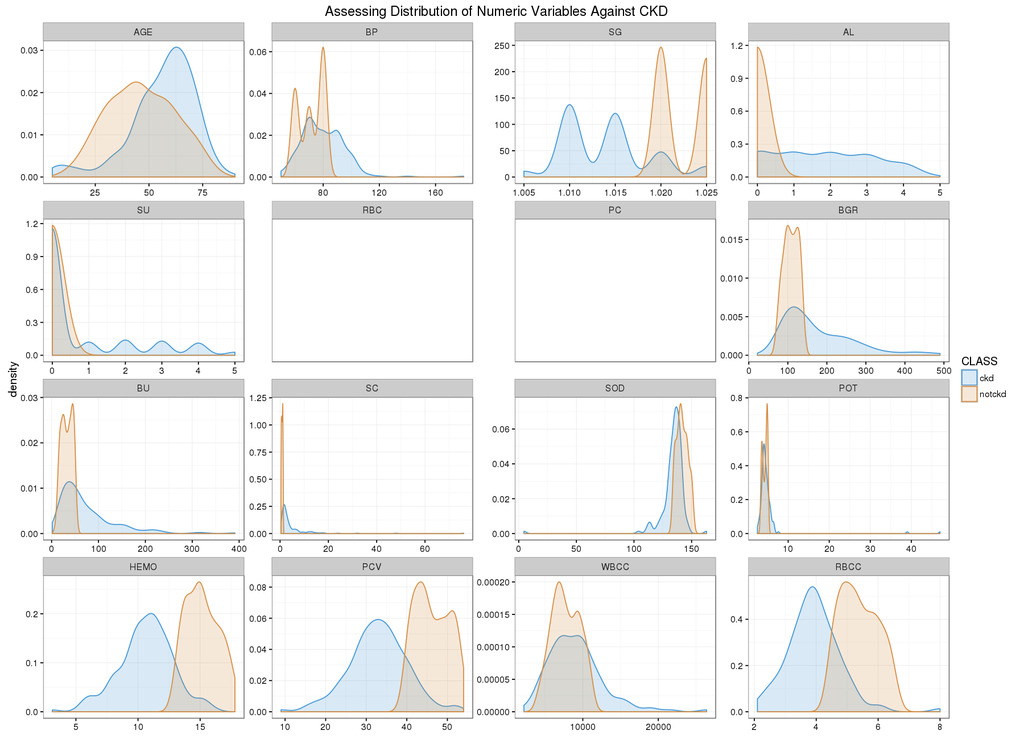

```r
options(repr.plot.width = 15, repr.plot.height = 11)

ggplot(data = numVar, aes(x = as.numeric(value), color = CLASS, fill = CLASS)) + geom_density(alpha = 0.2) +
              facet_wrap( ~ variable, scales = "free", ncol = 4) + theme_bw() +
              ggtitle("Assessing Distribution of Numeric Variables Against CKD") + xlab("") +
              scale_fill_manual(values=c("#4598d6", "#d68e45")) +
              scale_color_manual(values=c("#4598d6", "#d68e45"))
```

### 2.4 Convert from R to SparkR DataFrame

We can also covert a R data frame to a SparkR dataframe by using the `createDataFrame` command.

```r
spark_ckd <- createDataFrame(sqlContext, ckd_data)
typeof(spark_ckd) #spark_ckd is of S4 data type (will link to a tutorial on R data types)
head(spark_ckd)
```

'S4'

|  | AGE | BP | SG | AL | SU | RBC | PC | PCC | BA | BGR | BU | SC | SOD | POT | HEMO | PCV | WBCC | RBCC | HTN | DM | CAD | APPET | PE | ANE | CLASS |
| --- | --- | --- | --- | --- | --- | --- | --- | --- | --- | --- | --- | --- | --- | --- | --- | --- | --- | --- | --- | --- | --- | --- | --- | --- | --- |
| 1 | 33 | 80 | 1.025 | 0 | 0 | normal | normal | notpresent | notpresent | 128 | 38 | 0.6 | 135 | 3.9 | 13.1 | 45 | 6200 | 4.5 | no | no | no | good | no | no | notckd |
| 2 | 41 | 80 | 1.02 | 0 | 0 | normal | normal | notpresent | notpresent | 122 | 25 | 0.8 | 138 | 5 | 17.1 | 41 | 9100 | 5.2 | no | no | no | good | no | no | notckd |
| 3 | 52 | 80 | 1.02 | 0 | 0 | normal | normal | notpresent | notpresent | 128 | 30 | 1.2 | 140 | 4.5 | 15.2 | 52 | 4300 | 5.7 | no | no | no | good | no | no | notckd |
| 4 | 47 | 60 | 1.02 | 0 | 0 | normal | normal | notpresent | notpresent | 137 | 17 | 0.5 | 150 | 3.5 | 13.6 | 44 | 7900 | 4.5 | no | no | no | good | no | no | notckd |
| 5 | 43 | 80 | 1.025 | 0 | 0 | normal | normal | notpresent | notpresent | 81 | 46 | 0.6 | 135 | 4.9 | 13.9 | 48 | 6900 | 4.9 | no | no | no | good | no | no | notckd |
| 6 | 51 | 60 | 1.02 | 0 | 0 | ? | ? | notpresent | notpresent | 129 | 25 | 1.2 | 139 | 5 | 17.2 | 40 | 8100 | 5.9 | no | no | no | good | no | no | notckd |

For more information about how to use SparkR for machine learning, please refer to Azka's demo. For PySpark machine learning, please refer to Quan's demo.